# Forschungspraktikum 1+2: Computational Social Science

Tutorial 03: Describing Text-as-Data

Dr. Christian Czymara

We will continue working with the academic text prepared in the last tutorial. Please either load your results from last time or rerun your code (or the [solution](https://htmlpreview.github.io/?https://github.com/czymara/CSS_WS24/blob/main/tutorials/FoPra_CSS_tutorial_02_solution.html)) before starting this tutorial.

This tutorial will again use Czymara & Gorodzeisky (2024): [Hostility on Twitter in the Aftermath of Terror Attacks](https://link.springer.com/article/10.1007/s42001-024-00272-9).

## 0. Getting Started

Ensure you have the necessary R packages installed. We’ll use `quanteda` for text processing and its related packages `quanteda.textstats` and `quanteda.textplots` for descriptive text analysis. We’ll also use `stringr`, `dplyr`, and `ggplot2` for data manipulation and visualization. Install and load all required packages.

```r
packages <- c(
  "quanteda",             # text data preparation and analysis
  "quanteda.textstats",   # text statistics
  "quanteda.textplots",   # text visualizations
  "stringr",              # string manipulation
  "dplyr",                # data manipulation
  "ggplot2"               # data visualization
)

# install if necessary
install.packages(setdiff(packages, rownames(installed.packages())))

# load
lapply(packages, library, character.only = TRUE)
```

[output not shown]

## 1. Frequency Plots

We previously identified frequent terms in the DFM. Now, let’s visualize these findings.

### a) Total Frequency

Calculate the absolute frequency of terms in your text using `textstat_frequency()`.

```r
freq_CSS_art <- textstat_frequency(dfm_CSS_article, n = 50)

freq_CSS_art
```

```
##        feature frequency rank docfreq group
## 1       social        30    1       9   all
## 2      hostile        26    2       9   all
## 3      muslims        23    3       9   all
## 4       online        22    4       9   all
## 5       trends        22    4       8   all
## 6        media        20    6       9   all
## 7    attitudes        19    7       5   all
## 8  immigration        19    7       7   all
## 9       models        19    7       7   all
## 10      points        19    7       6   all
## 11       model        18   11       7   all
## 12     changes        17   12       8   all
## 13      toward        17   12       7   all
## 14      levels        17   12       8   all
```

[output cut: 36 more lines]

Then, use `ggplot2` to plot the 50 most frequent terms. How does the usage of these terms vary across the article?

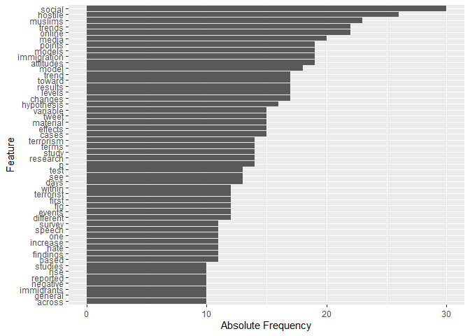

```r
ggplot(freq_CSS_art, aes(x = frequency, y = reorder(feature, frequency))) +
    geom_bar(stat = "identity") +
    labs(x = "Absolute Frequency", y = "Feature")
```

### b) Relative Frequency

The absolute frequency of a term can be influenced by the total number of words (words are likely to occur more often in longer texts). To adjust for this, calculate the relative frequency of terms using `dfm_weight()`, which provides a proportional view of word usage rather than counts.

```r
dfm_CSS_article_rel_freq <- dfm_weight(dfm_CSS_article, scheme = "prop") * 100

dfm_CSS_article_rel_freq
```

```
## Document-feature matrix of: 18 documents, 1,600 features (90.03% sparse) and 0 docvars.
##        features
## docs    httpsdoiorg101007s42001024002729  research   article aftermath
##   text1                        0.8064516 0.8064516 0.8064516 0.8064516
##   text2                        0         0.3412969 0         0
##   text3                        0         1.7123288 0         0
##   text4                        0         0.3448276 0         0
##   text5                        0         0.4016064 0         0
##   text6                        0         0.4566210 0         0.4566210
##        features
## docs    christian        s czymara12 anastasia gorodzeisky1  received
##   text1  1.612903 1.612903 0.8064516 0.8064516    0.8064516 0.8064516
##   text2  0        0        0         0            0         0
##   text3  0        0        0         0            0         0.3424658
##   text4  0        0        0         0            0         0
##   text5  0        0        0         0            0         0
##   text6  0        0        0         0            0         0
## [ reached max_ndoc ... 12 more documents, reached max_nfeat ... 1,590 more features ]
```

```r
freq_CSS_art_rel_freq <- textstat_frequency(dfm_CSS_article_rel_freq, n = 50)
```

Plot the 50 most frequent terms again and compare these results with those of the absolute frequency plot.

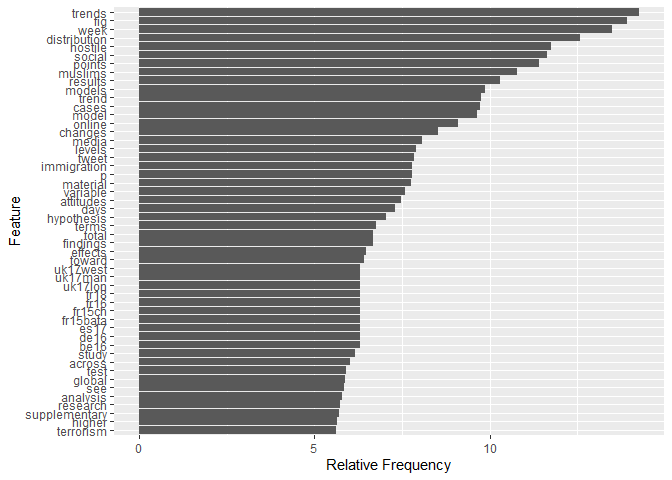

```r
ggplot(freq_CSS_art_rel_freq, aes(x = frequency, y = reorder(feature, frequency))) +
    geom_bar(stat = "identity") +
    labs(x = "Relative Frequency", y = "Feature")
```

## 2. TF-IDF

Use `dfm_tfidf()` to create a TF-IDF based on the DFM object. Compare the cell values of the DFM, the weighted DFM from exercise 1.b) and the TF-IDF.

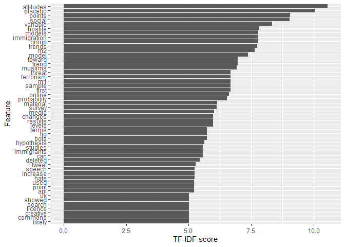

```r
tfidf_CSS_article <- dfm_tfidf(dfm_CSS_article)

freq_CSS_art_tfidf <- textstat_frequency(tfidf_CSS_article, n = 50, force = TRUE)

ggplot(freq_CSS_art_tfidf, aes(x = frequency, y = reorder(feature, frequency))) +
    geom_bar(stat = "identity") +
    labs(x = "TF-IDF score", y = "Feature")
```

## 3. Lexical Dispersion Plot

Now we want to see how the usage of words changes through the documents, i. e., within and across pages of the article. Use `textplot_xray()` to visualize the occurrence of *three* specific terms across your text. To this end, select three terms of interest (such as “immigration” in the example) or frequent keywords from your DFM.

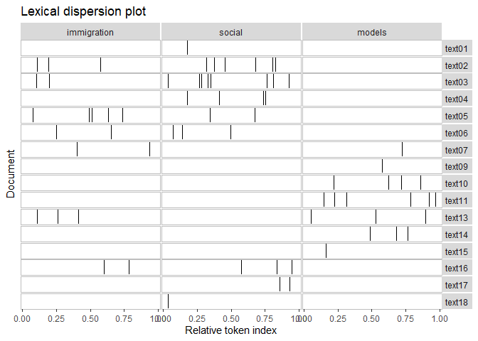

```r
docnames(toks_CSS_article) <- sprintf("text%02d", as.integer(gsub("text", "", docnames(toks_CSS_article)))) # this is optional: we rename the documents "text01" instead of "text1" so that the y-axis is ordered correctly in the plot

textplot_xray(
     kwic(toks_CSS_article, pattern = "immigration"),
     kwic(toks_CSS_article, pattern = names(topfeatures(dfm_CSS_article)[1])), # most frequent term in the DFM
     kwic(toks_CSS_article, pattern = "models"),
     sort = TRUE
     )
```

## 4. Word Co-occurrence

Next, we want to examine which words tend to occur together in our text.

### a) $n$-grams

As a first step, we want to generate *bigrams* to see pairs of words frequently occur together in the paper. Use `tokens_ngrams()` to create these bigrams.

```r
tokens_ngrams(toks_CSS_article)
```

```
## Tokens consisting of 18 documents.
## text01 :
##  [1] "httpsdoiorg101007s42001024002729_research"
##  [2] "research_article"
##  [3] "article_aftermath"
##  [4] "aftermath_christian"
##  [5] "christian_s"
##  [6] "s_czymara12"
##  [7] "czymara12_anastasia"
##  [8] "anastasia_gorodzeisky1"
##  [9] "gorodzeisky1_received"
## [10] "received_november"
## [11] "november_accepted"
## [12] "accepted_march"
## [ ... and 111 more ]
##
## text02 :
##  [1] "introduction_several" "several_major"        "major_conducted"
##  [4] "conducted_name"       "name_political"       "political_hit"
##  [7] "hit_europe"           "europe_recent"        "recent_years1"
## [10] "years1_resulting"     "resulting_dozens"     "dozens_fatalities"
## [ ... and 280 more ]
##
## text03 :
##  [1] "marketplace_ideas"   "ideas_one"           "one_plays"
##  [4] "plays_important"     "important_role"      "role_public"
##  [7] "public_political"    "political_discourse" "discourse_social"
## [10] "social_science"      "science_research"    "research_recently"
## [ ... and 279 more ]
##
## text04 :
##  [1] "first_set"              "set_studies"            "studies_exploits"
##  [4] "exploits_fact"          "fact_several"           "several_large"
##  [7] "large_survey"           "survey_programs"        "programs_hap"
## [10] "hap_pened"              "pened_unintentionally"  "unintentionally_active"
## [ ... and 277 more ]
##
## text05 :
##  [1] "types_disasters"       "disasters_attitudinal" "attitudinal_survey"
##  [4] "survey_studies"        "studies_shown"         "shown_potential"
##  [7] "potential_effects"     "effects_terrorism"     "terrorism_tend"
## [10] "tend_shortlived"       "shortlived_abate"      "abate_turkoglu"
## [ ... and 236 more ]
##
## text06 :
##  [1] "peaceful_ones"         "ones_may"              "may_leave"
##  [4] "leave_competing"       "competing_hypothesis"  "hypothesis_individual"
##  [7] "individual_actually"   "actually_update"       "update_views"
## [10] "views_thus"            "thus_become"           "become_hostile"
## [ ... and 206 more ]
##
## [ reached max_ndoc ... 12 more documents ]
```

Then, review the *first and last ten* bigrams or trigrams in the dataset.

```r
head(tokens_ngrams(toks_CSS_article[1], 2:3)[[1]], n = 10)
```

```
##  [1] "httpsdoiorg101007s42001024002729_research"
##  [2] "research_article"
##  [3] "article_aftermath"
##  [4] "aftermath_christian"
##  [5] "christian_s"
##  [6] "s_czymara12"
##  [7] "czymara12_anastasia"
##  [8] "anastasia_gorodzeisky1"
##  [9] "gorodzeisky1_received"
## [10] "received_november"
```

```r
tail(tokens_ngrams(toks_CSS_article[1], 2:3)[[1]], n = 10)
```

```
##  [1] "tel_aviv_university"            "aviv_university_tel"
##  [3] "university_tel_avivyafo"        "tel_avivyafo_israel"
##  [5] "avivyafo_israel_goethe"         "israel_goethe_university"
##  [7] "goethe_university_frankfurt"    "university_frankfurt_frankfurt"
##  [9] "frankfurt_frankfurt_main"       "frankfurt_main_germany"
```

### b) Frequency of Bigrams

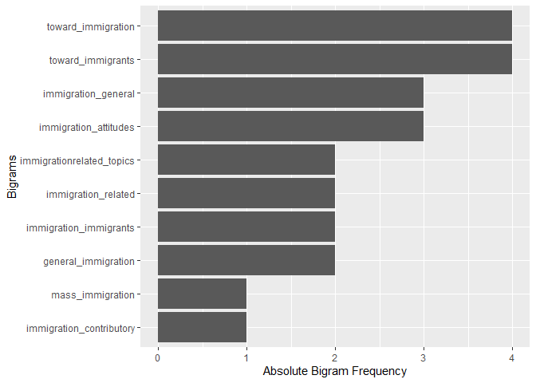

```r
dfm_bigram <- toks_CSS_article %>%
  tokens_ngrams(2) %>%
  dfm()

textstat_frequency(dfm_bigram) %>%
  filter(str_detect(feature, "immigr")) %>%
  head(10) %>%
  ggplot(aes(x = frequency, y = reorder(feature, frequency))) +
    geom_bar(stat = "identity") +
    labs(x = "Absolute Bigram Frequency", y = "Bigrams")
```

### c) Collocations

Collocations are word pairs that occur together more frequently than expected if random. Use `textstat_collocations()` to identify the top collocations in your text, ordered by their `lambda` statistic.

```r
collocations <- textstat_collocations(toks_CSS_article, size = 2)

collocations[order(collocations$lambda, decreasing = T), ]
```

```
##                   collocation count count_nested length    lambda        z
## 113                     et al     6            0      2 11.472697 5.628934
## 131          creative commons     4            0      2 11.105513 5.404483
## 164               christian s     3            0      2 10.854470 5.243041
## 165      intergroup relations     3            0      2 10.854470 5.243041
## 166        interrupted series     3            0      2 10.854470 5.243041
## 167               life course     3            0      2 10.854470 5.243041
## 184  1attack 2timesinceattack     2            0      2 10.518268 5.014233
## 185                atti tudes     2            0      2 10.518268 5.014233
## 186             blumer argues     2            0      2 10.518268 5.014233
## 187          christmas market     2            0      2 10.518268 5.014233
## 188         closer inspection     2            0      2 10.518268 5.014233
## 189         conflict interest     2            0      2 10.518268 5.014233
## 190              dif ferences     2            0      2 10.518268 5.014233
## 191               dimin ishes     2            0      2 10.518268 5.014233
```

[output cut: 211 more lines]

## 5. Feature Co-occurrence Networks

Lastly, we’ll create a Feature Co-occurrence Matrix (FCM) to measure how often certain features co-occur within a each page.

### a) Generate FCM

Create the FCM using `quanteda`’s `fcm()` function. Review its structure.

```r
fcm_CSS_article <- fcm(dfm_CSS_article)

head(fcm_CSS_article)
```

```
## Feature co-occurrence matrix of: 6 by 1,600 features.
##                                   features
## features                           httpsdoiorg101007s42001024002729 research
##   httpsdoiorg101007s42001024002729                                0        1
##   research                                                        0       11
##   article                                                         0        0
##   aftermath                                                       0        0
##   christian                                                       0        0
##   s                                                               0        0
##                                   features
## features                           article aftermath christian s czymara12
##   httpsdoiorg101007s42001024002729       1         1         2 2         1
##   research                               3         2         3 3         1
##   article                                1         1         4 4         1
##   aftermath                              0         0         2 2         1
##   christian                              0         0         1 5         2
##   s                                      0         0         0 1         2
##                                   features
## features                           anastasia gorodzeisky1 received
##   httpsdoiorg101007s42001024002729         1            1        1
##   research                                 1            1        6
##   article                                  1            1        1
##   aftermath                                1            1        1
##   christian                                2            2        2
##   s                                        2            2        2
## [ reached max_nfeat ... 1,590 more features ]
```

### b) Plot

Now we want to plot the result, but only the 50 most prevalent features for readability. First, filter for the 50 most frequent terms in the original DFM and assign them to a new object called `top_terms`. Second, use `fcm_select()` to reduce the FCM o these 50 terms. Finally, visualize the network with `textplot_network()`.

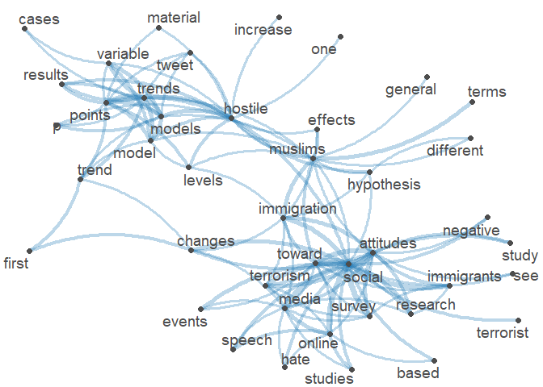

```r
top_terms <- names(topfeatures(dfm_CSS_article, 50))

fcm_top_term <- fcm_select(fcm_CSS_article, pattern = top_terms)

textplot_network(fcm_top_term, min_freq = 0.9, edge_alpha = 0.3, edge_size = 3)
```